# **CIV1299: Construction Safety: IoT and AI Solutions**

# **Lab 3: Autoencoders -- [100pts]**

### **Google Colab Link**

Click on the "Share" button in the top-right corner of the Colab interface. This will open a sharing dialog. In the sharing dialog, adjust the sharing settings by choosing `Anyone with the link` so that Anyone who has the link can access the notebook. Copy and paste the Shared Link here:

Link goes here: {https://drive.google.com/file/d/171a_-IS2uqPxivx73x-SEp26_sGI7wc4/view?usp=sharing }

### **Submission Guidelines**

- Submit an HTML file containing all your code, outputs, and answers. You can produce a HTML file directly from Google Colab. The Colab instructions are provided at the end of this document.
- If you encounter difficulties submitting the HTML file, please create a PDF document that includes all your code, results, and explanatory notes. You can generate a PDF from your Google Colab file by navigating to `File` -> `Print` and then selecting `Save as PDF`. Keep in mind that **the preferred method of submission is the HTML file, and submitting a PDF will lead into a 5% deduction of the total grade of this lab assignment.**
- We strongly recommend utilizing Google Colab for this assignment. If you choose to use Jupyter Notebook, kindly complete your work and upload the Jupyter Notebook file to Google Colab before submitting.
- Please thoroughly review your final submission to ensure that your answers are fully visible.
- Remember to provide a link to your Google Colab notebook within your submission.

### **Note:**

This notebook will walk you through many of the important features of PyTorch that you will need to use throughout the semester. In some cells you will see code blocks that look like this:

```
# =================== YOUR CODE STARTS HERE ==================


# ==================== YOUR CODE ENDS HERE ===================
```

You should replace the `pass` statement with your own code and leave the blocks intact, like this:

```
# =================== YOUR CODE STARTS HERE ==================
y = m * x + b

# ==================== YOUR CODE ENDS HERE ===================
```

When completing the notebook, please adhere to the following rules:

- Do not write your code or modify any code outside of code blocks.
- Run all cells before submitting. You will only get credit for code that has been run.

## 1. Assignment Overview

In this assignment, you will delve into the world of Autoencoders. Autoencoders are a type of neural network that are trained to attempt to copy their input to their output. They work by narrowing down the input into a lower-dimensional code and then reconstructing the output from this representation. This lab will guide you through the concepts of autoencoding, from simple architectures to more complex, variational autoencoders (VAEs).

You will get hands-on experience by implementing these models using PyTorch, training them on datasets, and analyzing their performance. By the end of this lab, you should be able to:

- Understand the theory and intuition behind Autoencoders and Variational Autoencoders.
- Implement and train Autoencoders and VAEs using PyTorch.
- Use Autoencoders for tasks such as image reconstruction, noise reduction, and data generation.
- Evaluate the performance of your Autoencoder models.

\

## Evaluation Criteria

Your proficiency in understanding and applying the concepts of Autoencoders will be assessed through a series of questions, each contributing to your final score. The distribution of points for each question is as follows:

- **Questions 1 and 2 (5 points each):** Your knowledge on transpose convolutional layers will be tested.
- **Question 3 (20 points):** This question requires you to complete the architecture of a Convolutional Autoencoder. You will need to apply your understanding of CNNs and autoencoders to construct a functional model.
- **Question 4 (20 points):** You will write the training code for the Convolutional Autoencoder you defined in Question 3, demonstrating your ability to implement training loops and optimization.
- **Question 5 (20 points):** You will develop the training code for a Denoising Autoencoder. This will test your skills in enhancing autoencoder architectures to remove noise from input data.
- **Question 6 (30 points):** In this final question, you are presented with a code snippet for the architecture of a Variational Autoencoder containing ten errors. Your task is to identify and correct all errors, showcasing your attention to detail and understanding of Autoencoders.

## 2. Convolutional Autoencoder

We already introduced the autoencoders and talked about their architecture and their Training in the PreLab 3. We also learned Convolution Transpose in Convolutional Autoencoders there.

When working with image data it is often better to use a convolutional neural network and take advantage of the spatial relationships. The architecture for the encoder stage of a convolutional autoencoder will consist of standard convolutional layers that we have seen in our previous architectures. The decoder step will be a bit more tricky since we need a way to increase the resolution.

Similar to the PreLab, we will use code that we have seen when working with MNIST data.

```python
# Initial setup
import numpy as np
import torch
import torch.nn as nn
import torch.nn.functional as F
import torch.optim as optim
import matplotlib.pyplot as plt
from torchvision import datasets, transforms

mnist_data = datasets.MNIST('data', train=True, download=True, transform=transforms.ToTensor())
mnist_data = list(mnist_data)[:4096]
```

```
Downloading http://yann.lecun.com/exdb/mnist/train-images-idx3-ubyte.gz
Downloading http://yann.lecun.com/exdb/mnist/train-images-idx3-ubyte.gz to data/MNIST/raw/train-images-idx3-ubyte.gz
```

```
Extracting data/MNIST/raw/train-images-idx3-ubyte.gz to data/MNIST/raw

Downloading http://yann.lecun.com/exdb/mnist/train-labels-idx1-ubyte.gz
Downloading http://yann.lecun.com/exdb/mnist/train-labels-idx1-ubyte.gz to data/MNIST/raw/train-labels-idx1-ubyte.gz
```

```
Extracting data/MNIST/raw/train-labels-idx1-ubyte.gz to data/MNIST/raw

Downloading http://yann.lecun.com/exdb/mnist/t10k-images-idx3-ubyte.gz
```

```
Downloading http://yann.lecun.com/exdb/mnist/t10k-images-idx3-ubyte.gz to data/MNIST/raw/t10k-images-idx3-ubyte.gz
```

```
Extracting data/MNIST/raw/t10k-images-idx3-ubyte.gz to data/MNIST/raw
```

```
Downloading http://yann.lecun.com/exdb/mnist/t10k-labels-idx1-ubyte.gz
Downloading http://yann.lecun.com/exdb/mnist/t10k-labels-idx1-ubyte.gz to data/MNIST/raw/t10k-labels-idx1-ubyte.gz
```

```
Extracting data/MNIST/raw/t10k-labels-idx1-ubyte.gz to data/MNIST/raw
```

First, let's test your knowlege on Convolution Transpose in what follows.

## **Question 1 -- [5 pts]:**

Similar to PreLab 3, using the PyTorch library, create a transpose convolutional layer with the following specific parameters.

- Number of input channels: 32
- Number of output channels: 16
- Kernel size: 6
- Stride: 2
- Output padding: 1
- Padding: 2

```python
# =================== YOUR CODE STARTS HERE ==================
# convt = nn.ConvTranspose2d(in_channels=...)


convt = nn.ConvTranspose2d(in_channels=32,out_channels=16,kernel_size=6,
                           stride=2,output_padding=1,padding=2)



# ==================== YOUR CODE ENDS HERE ===================
x = torch.randn(16, 32, 64, 64) # BCHW
y = convt(x)
y.shape
```

```
torch.Size([16, 16, 129, 129])
```

## **Question 2 -- [5 pts]:**

Try to verify the output size (height and width) of `y` using the following equation. (Simply substitute every number in the equation to prove that you get the same output size as above. You do not have to provide any code.)

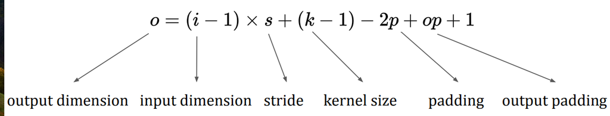

```python
# =================== YOUR ANSWER STARTS HERE ==================

o = (64-1) * 2 + (6-1) - (2*2) + 1 + 1

print(o)
# ==================== YOUR ANSWER ENDS HERE ===================
```

```
129
```

### 2.1. Implementation of a Convolutional Autoencoder

## **Question 3 -- [20 pts]:**

Your task here is to demonstrate your understanding of convolution transpose operations by building a **convolutional autoencoder**. This autoencoder should exclusively utilize convolutional layers. Provided below is a skeleton of the Autoencoder class. Your job is to complete the definitions of the encoder and decoder within the class.

Guidelines:

Ensure that the final layer of the decoder outputs the reconstructed image with the appropriate dimensions and activation function.

Here is the structure you need to complete:

```python
class Autoencoder(nn.Module):
    def __init__(self):
        super(Autoencoder, self).__init__()
        # =================== YOUR CODE STARTS HERE ==================
        self.encoder = nn.Sequential(
             nn.Conv2d(1, 16, kernel_size=3, stride=2, padding=1),
             nn.ReLU(),
             nn.Conv2d(16, 32, kernel_size=3, stride=2, padding=1),
             nn.ReLU(),
             nn.Conv2d(32, 64, kernel_size=7)
         )
        # # ==================== YOUR CODE ENDS HERE ===================

        # =================== YOUR CODE STARTS HERE ==================

        self.decoder = nn.Sequential(
            nn.ConvTranspose2d(64, 32, kernel_size=7),
            nn.ReLU(),
            nn.ConvTranspose2d(32, 16, kernel_size=3, stride=2, padding=1, output_padding=1),
            nn.ReLU(),
            nn.ConvTranspose2d(16, 1, kernel_size=3, stride=2, padding=1, output_padding=1),
            nn.Sigmoid()
        )


        # ==================== YOUR CODE ENDS HERE ===================

    def forward(self, x):
        x = self.encoder(x)
        x = self.decoder(x)
        return x
```

### 2.2. Training a Convolutional Autoencoder

## **Question 4 -- [20 pts]:**

Please complete the following training code for the defined convolutional autoencoder.

**Hint:** The training of the convolutional autoencoder will be the same as with the fully-connected autoencoder architecture. Pay special attention to the following key aspects:

- A mean square error loss (criterion) and Adam optimizer (optimizer) are defined for you.
- train_loader is provided for loading the MNIST dataset in batches.
- Within the training loop, you need to implement the forward pass, loss computation, backpropagation, and optimizer steps.
- Don’t forget to clear the gradients after each optimizer step.
- After each epoch, print the epoch number and the loss for that epoch.
- Store and return the output images and reconstructions at each epoch.

```python
def train(model, num_epochs=5, batch_size=64, learning_rate=1e-3):
    torch.manual_seed(42)
    criterion = nn.MSELoss() # mean square error loss
    optimizer = torch.optim.Adam(model.parameters(),
                                 lr=learning_rate,
                                 weight_decay=1e-5)
    train_loader = torch.utils.data.DataLoader(mnist_data,
                                               batch_size=batch_size,
                                               shuffle=True)
    outputs = []
    # =================== YOUR CODE STARTS HERE ==================
    # Hint: You need to define (two) nested `for` loops.
    for epoch in range(num_epochs):
        for data in train_loader:
          img,_ = data
          recon = model(img)

          loss = criterion(recon,img)
          optimizer.zero_grad()
          loss.backward()

          optimizer.step()


          outputs.append((epoch, img, recon))
        print(f"Epoch [{epoch+1}/{num_epochs}], Loss: {loss.item():.4f}")



    # ==================== YOUR CODE ENDS HERE ===================
    return outputs
```

Now, we can train this network.

```python
model = Autoencoder()
outputs = train(model, num_epochs=20)
```

```
Epoch [1/20], Loss: 0.0680
Epoch [2/20], Loss: 0.0676
Epoch [3/20], Loss: 0.0576
Epoch [4/20], Loss: 0.0389
Epoch [5/20], Loss: 0.0280
Epoch [6/20], Loss: 0.0201
Epoch [7/20], Loss: 0.0166
Epoch [8/20], Loss: 0.0157
Epoch [9/20], Loss: 0.0149
Epoch [10/20], Loss: 0.0115
Epoch [11/20], Loss: 0.0092
Epoch [12/20], Loss: 0.0092
Epoch [13/20], Loss: 0.0103
Epoch [14/20], Loss: 0.0082
Epoch [15/20], Loss: 0.0076
Epoch [16/20], Loss: 0.0079
Epoch [17/20], Loss: 0.0071
Epoch [18/20], Loss: 0.0065
Epoch [19/20], Loss: 0.0061
Epoch [20/20], Loss: 0.0061
```

Let's look at the training progression: that is, the reconstructed images at various points of training:

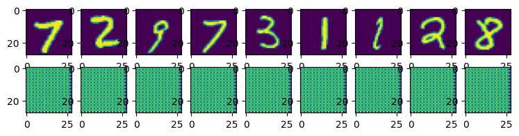

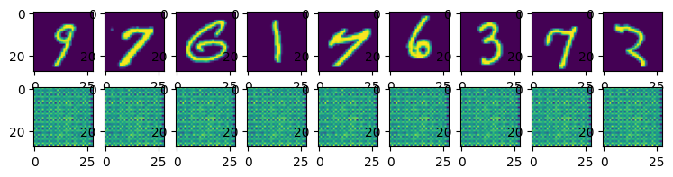

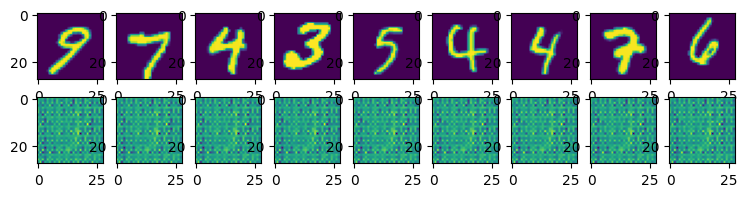

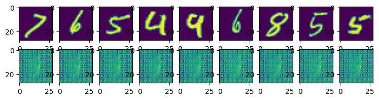

```python
max_epochs = 20
for k in range(0, max_epochs, 5):
    plt.figure(figsize=(9, 2))
    imgs = outputs[k][1].detach().numpy()
    recon = outputs[k][2].detach().numpy()
    for i, item in enumerate(imgs):
        if i >= 9: break
        plt.subplot(2, 9, i+1)
        plt.imshow(item[0])

    for i, item in enumerate(recon):
        if i >= 9: break
        plt.subplot(2, 9, 9+i+1)
        plt.imshow(item[0])
```

## 3. Denoising Autoencoder

In this section, we'll explore the application of an autoencoder for image denoising. You'll add noise to images and train an autoencoder to remove this noise!

## **Question 5 -- [20 pts]:**

Your task is to complete the training code for a denoising autoencoder. This involves modifying the standard autoencoder training process to handle noisy input images while still aiming to reconstruct the original, noise-free images.

**Your task:**

Complete the training code for a denoising autoencoder. Here are the steps you need to follow:

1. Initialize Noise Level: Define a noise factor that will determine the intensity of the noise added to the images. (E.g., noise = 0.5)
2. Modify Training Loop for Noisy Images:
- Within the training loop, for each batch of images, add Gaussian noise (using the noise factor) to create noisy versions of the images.
- Ensure that the noisy images are clipped to maintain valid image pixel values.
1. Training Process:
- Pass the noisy images through the model to obtain the reconstructions.
- Compute the loss using the original (clean) images and the reconstructions.
- Perform backpropagation and update the model parameters using the optimizer.
- Set the gradients to zero after each optimization step.
1. Track Training Progress:
- After each epoch, print the epoch number and the current loss.
- Store the epoch number, noisy images, and their reconstructions for later analysis and visualization.
1. Return the Results:
- After completing all epochs, return the stored outputs.
- After each epoch, print the epoch number and the loss for that epoch.

More Hint!:

Here's how you should add the noise:

```
img_noisy = img + noise * torch.randn(*img.shape)
img_noisy = np.clip(img_noisy, 0, 1)
```

```python
def train(model, num_epochs=5, batch_size=64, learning_rate=1e-3):
    torch.manual_seed(42)
    criterion = nn.MSELoss() # mean square error loss
    optimizer = torch.optim.Adam(model.parameters(),
                                 lr=learning_rate,
                                 weight_decay=1e-5)
    train_loader = torch.utils.data.DataLoader(mnist_data,
                                               batch_size=batch_size,
                                               shuffle=True)
    noise = 0.5
    outputs = []
    # =================== YOUR CODE STARTS HERE ==================
    # Hint: Again, you need to define two nested `for` loops.
    # Hint: You can create the nosiy image like this: img_noisy = img + noise * torch.randn(*img.shape)
    #       followed by img_noisy = np.clip(img_noisy, 0, 1). The reconstructed image would be this noisy
    #       image passed through our model (defined autoencoder.)

    for epoch in range(num_epochs):
        for data in train_loader:
            img, _ = data
            img_noisy = img + noise * torch.randn(*img.shape)
            img_noisy = torch.clip(img_noisy, 0, 1)
            recon = model(img_noisy)
            loss = criterion(recon, img)
            optimizer.zero_grad()
            loss.backward()
            optimizer.step()

        outputs.append((epoch, img_noisy, recon))
        print(f"Epoch [{epoch+1}/{num_epochs}], Loss: {loss.item():.4f}")




    # ==================== YOUR CODE ENDS HERE ===================
    return outputs
```

```python
# train denoising autoencoder
model = Autoencoder()
outputs = train(model, num_epochs=20)
```

```
Epoch [1/20], Loss: 0.0679
Epoch [2/20], Loss: 0.0610
Epoch [3/20], Loss: 0.0696
Epoch [4/20], Loss: 0.0690
Epoch [5/20], Loss: 0.0666
Epoch [6/20], Loss: 0.0619
Epoch [7/20], Loss: 0.0518
Epoch [8/20], Loss: 0.0385
Epoch [9/20], Loss: 0.0303
Epoch [10/20], Loss: 0.0294
Epoch [11/20], Loss: 0.0247
Epoch [12/20], Loss: 0.0240
Epoch [13/20], Loss: 0.0219
Epoch [14/20], Loss: 0.0198
Epoch [15/20], Loss: 0.0175
Epoch [16/20], Loss: 0.0199
Epoch [17/20], Loss: 0.0174
Epoch [18/20], Loss: 0.0181
Epoch [19/20], Loss: 0.0168
Epoch [20/20], Loss: 0.0176
```

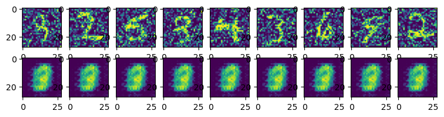

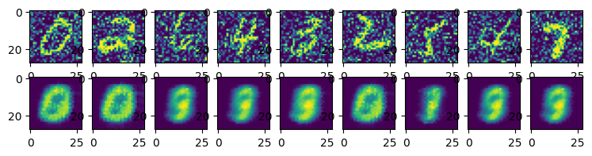

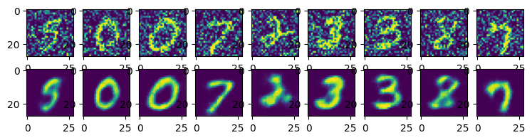

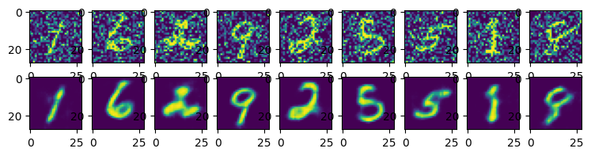

```python
# reconstructed images at various parts of training
for k in range(0, max_epochs, 5):
    plt.figure(figsize=(9, 2))
    imgs = outputs[k][1].detach().numpy()
    recon = outputs[k][2].detach().numpy()
    for i, item in enumerate(imgs):
        if i >= 9: break
        plt.subplot(2, 9, i+1)
        plt.imshow(item[0])

    for i, item in enumerate(recon):
        if i >= 9: break
        plt.subplot(2, 9, 9+i+1)
        plt.imshow(item[0])
```

### Testing on new images

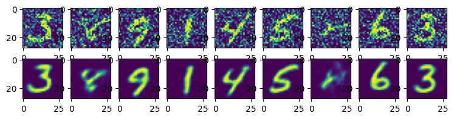

```python
batch_size = 64

mnist_data = datasets.MNIST('data', train=True, download=True, transform=transforms.ToTensor())
mnist_data = list(mnist_data)[4096:4160]

test_loader = torch.utils.data.DataLoader(mnist_data,
                                           batch_size=batch_size,
                                           shuffle=True)
# obtain one batch of test images
dataiter = iter(test_loader)
img, labels = next(dataiter)

# add noise to the test images
noise = 0.5
img_noisy = img + noise * torch.randn(*img.shape)
img_noisy = np.clip(img_noisy, 0, 1)

# get sample outputs
recon = model(img_noisy)
# prep images for display
img_noisy = img_noisy.numpy()
recon = recon.detach().numpy()

# reconstructed images at various parts of training
for k in range(1):
    plt.figure(figsize=(9, 2))

    for i, item in enumerate(img_noisy):
        if i >= 9: break
        plt.subplot(2, 9, i+1)
        plt.imshow(item[0])

    for i, item in enumerate(recon):
        if i >= 9: break
        plt.subplot(2, 9, 9+i+1)
        plt.imshow(item[0])
```

Autoencoders are well suited for extracting compressed representations of images and can correct things that don't match the expectation. This approach can be extended to other applications such as handling object occlusion, or filling in missing segments of an image.

## 4. Variational Autoencoder

The Variational Autoencoder (VAE) is an advanced form of autoencoder with the unique ability to generate new samples that are similar to the original dataset. In the context of the attached image, let's break down how the VAE operates and the specific components that allow it to function as a generative model:

1. **Encoding Network (conv):** The encoding network takes an input image, in this case, a picture of a cat, and passes it through convolutional layers (denoted as "conv"). This network compresses the image into a lower-dimensional space, capturing the most significant features. The encoding network's output is not just a single point but a distribution described by the next two components.
2. **Mean and Standard Deviation Vectors:** The encoder produces two vectors representing the parameters of a Gaussian distribution: a mean (𝜇) vector and a standard deviation (𝜎) vector. These vectors describe where the encoded representation of the input image lies in the latent space and how it's spread out. The Gaussian distribution is chosen because of its mathematical properties, which simplify the sampling process and help in regularizing the latent space.
3. **Sampled Latent Vector:** Instead of a deterministic output, we get a random sample from the Gaussian distribution defined by our mean and standard deviation vectors. This is what makes the VAE variational—it introduces variability by sampling from the distribution. This step is crucial for the generative aspect of the VAE, as it allows the model to produce new images that are variations of the input.
4. **Decoding Network (deconv):** The sampled latent vector is then passed to the decoding network, which typically consists of deconvolutional (or transposed convolutional) layers. The decoder takes the sampled latent vector and reconstructs it back into an image. For the VAE to work effectively, the decoder must be able to take any point from the latent space and map it back to a plausible image.
5. **Output Image:** The output is a reconstructed image that, ideally, closely resembles the input. However, because we're sampling from a distribution, the VAE can also generate new images that weren't in the training set by picking different points in the latent space.

To ensure the encoder produces a latent space that follows a unit Gaussian distribution, a constraint is enforced using the Kullback-Leibler (KL) divergence in the loss function. The KL divergence measures how one probability distribution diverges from a second, expected probability distribution. In the case of VAEs, it helps to ensure that the latent vectors follow the desired distribution, enabling the model to sample effectively and generate new data points.

The figure below demonstrates the flow from input to the encoded representation, through sampling and back to the reconstructed output. The VAE's power lies in its ability to not just reconstruct inputs but also to explore the latent space and create new instances that are similar to the original data, making it a powerful tool for generative tasks.

[figure not shown]

```python
# train data
train_loader = torch.utils.data.DataLoader(
    datasets.MNIST('data', train=True, download=True,
                   transform=transforms.ToTensor()),
                   batch_size=64, shuffle=True)

# test data
test_loader = torch.utils.data.DataLoader(
    datasets.MNIST('data', train=False, transform=transforms.ToTensor()),
    batch_size=64, shuffle=True)
```

## **Question 6 -- [30 pts]:**

The code snippet provided below contains ten errors, (Hint: seven of which are numerical.)

Your task is to meticulously review the code, identify, and correct all the mistakes. Correct each error to earn 3 points.

```python
# dimensions of latent space
zdim = 25

# Variational Autoencoder
class VAE(nn.Module):
    def __init__(self):
        super(VAE, self).__init__()

        # =================== START LOOKING FOR ERRORS HERE ==================
        # encoder
        self.fc1 = nn.Linear(28 * 28, 350) # Correcting the input dimension of MNIST to 28 x 28
        self.fc2m = nn.Linear(350, zdim)  # mu layer
        self.fc2s = nn.Linear(350, zdim)  # sd layer
        self.relu = nn.ReLU()

        # decoder
        self.fc3 = nn.Linear(zdim, 350)
        self.fc4 = nn.Linear(350, 28 * 28) #Correcting according to MNIST
        self.sigmoid = nn.Sigmoid()

    def encode(self, x):
        h1 = self.relu(self.fc1(x))
        return self.fc2m(h1), self.fc2s(h1) #Typically it's better to keep latent spaces linear(removing ReLU)

    # reparameterize
    def reparameterize(self, mu, logvar):
        if self.training:
            std = logvar.mul(0.5).exp_()
            eps = std.data.new(std.size()).normal_()
            return eps.mul(std).add_(mu)
        else:
            return mu

    def decode(self, z):
        h3 = self.relu(self.fc3(z))
        return self.sigmoid(self.fc4(h3)) #Only signmoid should be used. Removing ReLU

    def forward(self, x):
        mu, logvar = self.encode(x.view(-1, 28 * 28)) #Incorrect dimension. should be 28 x 28. 1 should be -1
        # =================== END LOOKING FOR ERRORS HERE ==================
        z = self.reparameterize(mu, logvar)
        return self.decode(z), mu, logvar
```

As mentioned previously, the loss function for VAE are unique and use Kullback-Leibler divergence measure to force distribution to match unit Gaussian.

```python
def loss_function(recon_x, x, mu, logvar):
    bce = F.binary_cross_entropy(recon_x, x.view(-1, 28 * 28))
    kld = -0.5 * torch.sum(1 + logvar - mu.pow(2) - logvar.exp())
    kld /= batch_size * 28 * 28
    return bce + kld
```

```python
def train(model, num_epochs = 1, batch_size = 64, learning_rate = 1e-3):
    model.train() #train mode
    torch.manual_seed(42)

    train_loader = torch.utils.data.DataLoader(datasets.MNIST('data',
               train=True, download=True, transform=transforms.ToTensor()),
               batch_size = batch_size, shuffle = True)

    optimizer = optim.Adam(model.parameters(), learning_rate)

    for epoch in range(num_epochs):
      for data in train_loader:
          img, _ = data

          recon, mu, logvar = model(img)
          loss = loss_function(recon, img, mu, logvar)
          loss.backward()
          optimizer.step()
          optimizer.zero_grad()

      print('Epoch:{}, Loss:{:.4f}'.format(epoch+1, float(loss)))
```

```python
batch_size = 64

model = VAE()

# On CPU, the following training code might take some time to execute (~12 minutes). So, please be patient!
train(model, num_epochs = 30, batch_size = batch_size)
```

```
Epoch:1, Loss:0.1569
Epoch:2, Loss:0.1408
Epoch:3, Loss:0.1239
Epoch:4, Loss:0.1227
Epoch:5, Loss:0.1189
Epoch:6, Loss:0.1102
Epoch:7, Loss:0.1271
Epoch:8, Loss:0.1212
Epoch:9, Loss:0.1192
Epoch:10, Loss:0.1242
Epoch:11, Loss:0.1257
Epoch:12, Loss:0.1136
Epoch:13, Loss:0.1096
Epoch:14, Loss:0.1188
Epoch:15, Loss:0.1106
Epoch:16, Loss:0.1086
Epoch:17, Loss:0.1116
Epoch:18, Loss:0.1162
Epoch:19, Loss:0.1119
Epoch:20, Loss:0.1183
Epoch:21, Loss:0.1024
Epoch:22, Loss:0.1137
Epoch:23, Loss:0.1104
Epoch:24, Loss:0.1079
Epoch:25, Loss:0.1126
Epoch:26, Loss:0.1141
Epoch:27, Loss:0.1277
Epoch:28, Loss:0.1199
Epoch:29, Loss:0.1159
Epoch:30, Loss:0.1135
```

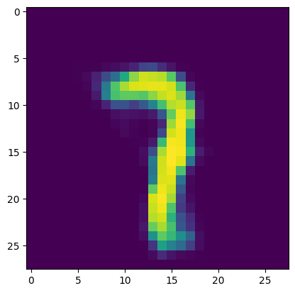

```python
# generate random samples in the latent space
model.eval()
sample = torch.randn(64, zdim)
sample = model.decode(sample)

import matplotlib.pyplot as plt
imgs = sample.data.view(64, 28, 28).numpy()
plt.imshow(imgs[4])
```

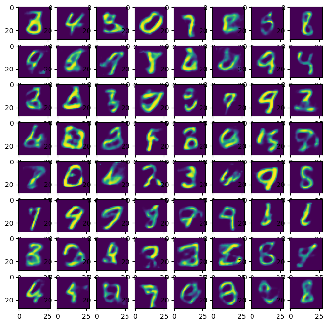

```python
# display images
for k in range(1):
    plt.figure(figsize=(8, 8))

    for i, item in enumerate(imgs):
        plt.subplot(8, 8, i+1)
        plt.imshow(item)
```

To conclude, we have explored a variety of autoencoder architectures throughout this assignment. We delved into stacked, convolutional, denoising, and variational autoencoders, each offering unique benefits and limitations. By understanding these differences, you can strategically combine elements from each type to construct an optimized architecture tailored to the specific requirements of your task at hand.

# Saving to HTML

Detailed instructions for saving to HTML can be found [here](https://stackoverflow.com/questions/53460051/convert-ipynb-notebook-to-html-in-google-colab/64487858#64487858). Provided below are a summary of the instructions:

(1) download your ipynb file by clicking on File->Download .ipynb

(2) reupload your file to the temporary Google Colab storage (you can access the temporary storage from the tab to the left)

(3) run the following:

```python
%%shell
jupyter nbconvert --to html /content/LAB3_CIV1299_Autoencoders.ipynb
```

(4) the html file will be available for download in the temporary Google Colab storage

(5) review the html file and make sure all the results are visible before submitting your assignment to Quercus